# Multiple Linear Regression, Housing

Ryan Greenup

25 March 2018

# Preamble

First as a matter of housekeeping, we need to load in pertinent packages and set the working directory

```r
# Load Packages -----------------------------------------------------------

if(require('pacman')){
  library('pacman')
}else{
  install.packages('pacman')
  library('pacman')
}
```

```r
pacman::p_load(xts, sp, gstat, ggplot2, rmarkdown, reshape2, ggmap,
               parallel, dplyr, plotly)


# Set the Working Directory -----------------------------------------------

set_wd <- function() {

  #Install the RStudio API package

  if(require('rstudioapi')){
    library('rstudioapi')
  }else{
    install.packages('rstudioapi')
    library('rstudioapi')
  }

  #Use the Rstudio API to get the working directory

  current_path <- getActiveDocumentContext()$path
  setwd(dirname(current_path ))
  print( getwd() )
}

#set_wd()

# Import the Data Set -----------------------------------------------------
house.df <- read.csv("house2018.csv", header = TRUE, sep = ",")
house.df <- house.df[,c("price", "sqm", "bedrooms")]

    ##Create Assignments
    price <- house.df$price
    sqm   <- house.df$sqm
    broom <- house.df$bedrooms
```

# Inspect the Data

First we will Inspect the data:

```r
head(house.df)
```

```
##     price sqm bedrooms
## 1 1143000 166        2
## 2 1142000 188        4
## 3 1148000 161        3
## 4  947000 183        3
## 5 1198000 197        3
## 6 1146000 165        3
```

## Use Plotting Tools

### Base Plot

A base plot can be used to get a rough idea for the distribution of the data:

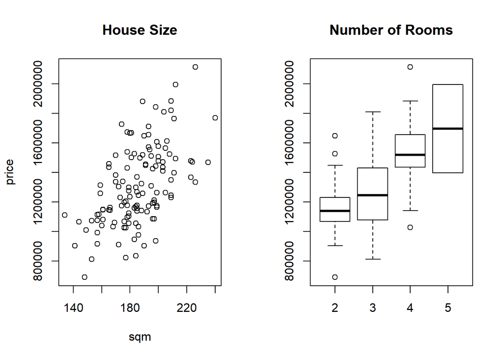

```r
layout(matrix(nrow = 1, 1:2))
plot(y = price, x = sqm, main = "House Size")
boxplot(price~broom, main = "Number of Rooms")
```

### GGplot

GGplot will allow us to look at all the data together:

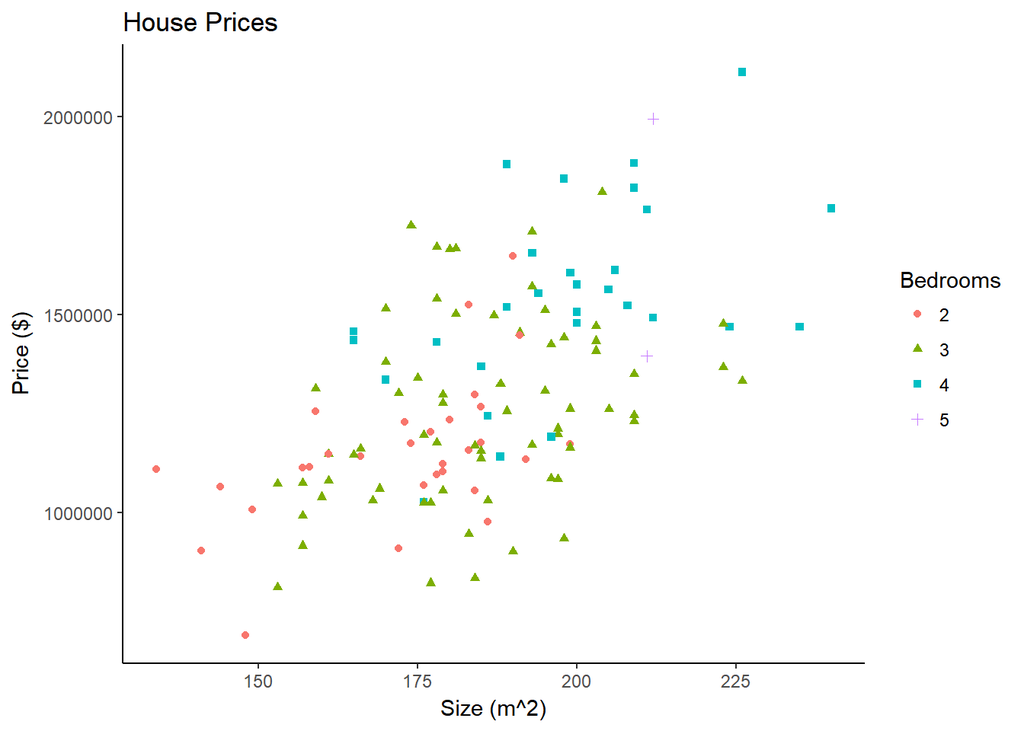

```r
house.df$bedrooms <- as.factor(house.df$bedrooms)
ggplot(data = house.df, aes(x = sqm, y = price, col = bedrooms, shape = bedrooms)) +
  geom_point() +
  labs(col = "Bedrooms", shape = "Bedrooms") +
  xlab("Size (m^2)") +
  ylab("Price ($)") +
ggtitle("House Prices") +
  theme_classic()
```

## Discussion

By looking at the plots, it appears that both trends of price relative to these variables are linear, thus geometrically it is likely the appropriate model is a plane.

Hence a muliple linear regression will be fitted to the data.

# Fit a model

A multiple linear regression can be fitted to the data thusly:

```r
#Remember that bedrooms MUST be a factor, NOT a continuous variable

houses.lm <- lm(price ~ sqm + broom)
summary(houses.lm)
```

```
##
## Call:
## lm(formula = price ~ sqm + broom)
##
## Residuals:
##     Min      1Q  Median      3Q     Max
## -458030 -153510  -13589  112823  484592
##
## Coefficients:
##             Estimate Std. Error t value Pr(>|t|)
## (Intercept)   -65342     177461  -0.368    0.713
## sqm             5362       1087   4.932 2.53e-06 ***
## broom         124239      29452   4.218 4.69e-05 ***
## ---
## Signif. codes:  0 '***' 0.001 '**' 0.01 '*' 0.05 '.' 0.1 ' ' 1
##
## Residual standard error: 210800 on 125 degrees of freedom
## Multiple R-squared:  0.3944, Adjusted R-squared:  0.3848
## F-statistic: 40.71 on 2 and 125 DF,  p-value: 2.423e-14
```

Thus the best fitting multiple linear regression model is:

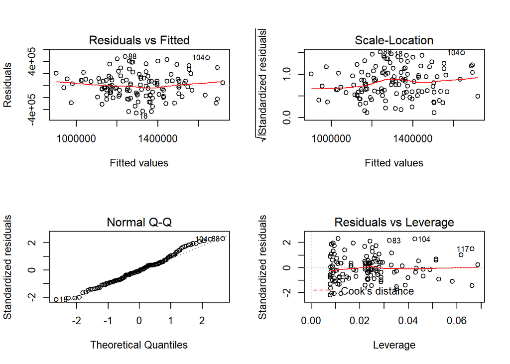

```r
layout(matrix(nrow =2, 1:4))
plot(houses.lm)
```

```r
houses.lm %>% resid() %>% shapiro.test()
```

```
##
##  Shapiro-Wilk normality test
##
## data:  .
## W = 0.98601, p-value = 0.2142
```

# Plot the Model

## Predict over a data frame

In order to plot this model, it is necessary to predict the model over a data frame.

```r
independent.df <- data.frame("sqm" = seq(from = 100, to = 200, length.out = 999),
                      "broom" = seq(from = 3, to = 3, length.out = 999))

#Remember bedrooms is a factor (i.e. discrete variable), that may or may not
#need to be adjusted
#independent.df$broom <- as.factor(independent.df$broom)

price.mod.df <- predict(object = houses.lm, newdata = independent.df)
price.mod.df <- data.frame("Model.Price" = price.mod.df,
                           "Size" = independent.df)

head(price.mod.df)
```

```
##   Model.Price Size.sqm Size.broom
## 1    843601.5 100.0000          3
## 2    844138.8 100.1002          3
## 3    844676.1 100.2004          3
## 4    845213.4 100.3006          3
## 5    845750.6 100.4008          3
## 6    846287.9 100.5010          3
```

## Create the Base Plots

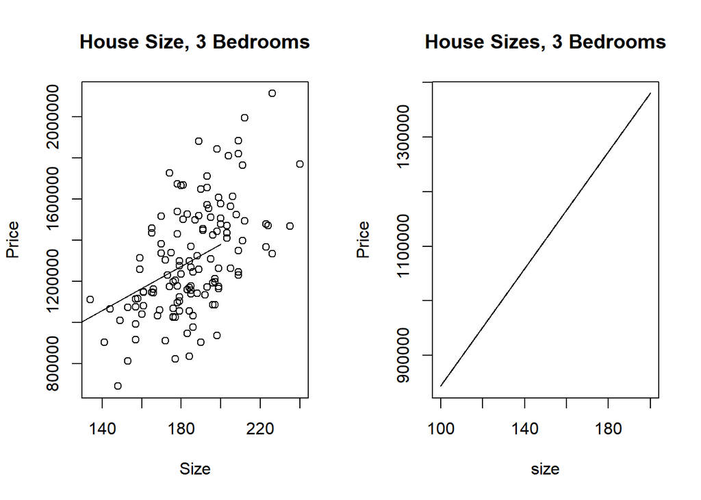

```r
layout(matrix(nrow = 1, 1:2))
plot(y = price, x = sqm,
     main = "House Size, 3 Bedrooms",
     xlab = "Size", ylab = "Price")
lines(y = price.mod.df$Model.Price,
      x = price.mod.df$Size.sqm)
plot(y = price.mod.df$Model.Price,
     x = price.mod.df$Size.sqm,
     pch = ".", main = "House Sizes, 3 Bedrooms",
     xlab = "size", ylab = "Price")
```

## Create GGPlots for better visualisation

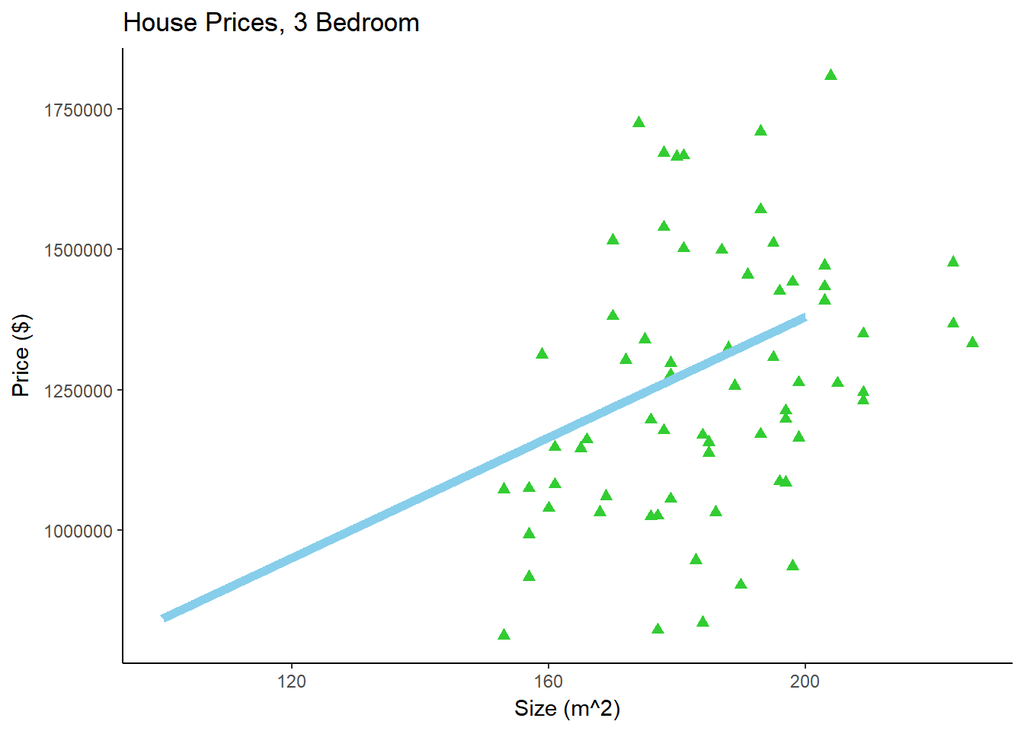

```r
house.df.b3 <- subset(house.df, bedrooms == 3)

ggplot(data = house.df.b3, aes(x = sqm, y = price, shape = "b")) +
  geom_point(col = "limegreen", shape = 17, size = 2) +
  xlab("Size (m^2)") +
  ylab("Price ($)") +
ggtitle("House Prices, 3 Bedroom") +
  theme_classic() +
  geom_line(data = price.mod.df, mapping = aes(x = Size.sqm, y = Model.Price), col = "skyblue", lwd = 2)
```

# Conclusion

A multiple linear regression is a pretty poor model of house prices relative to size and number of bedrooms

This is demonstrated by observing the model at a cross section taken for 3 bedroom houses, the linear model only barely follows the data trend.